# W3

## (c) Use the lm() function to perform a multiple linear regression with mpg as the response and all other variables except name as the predictors. Use the summary() function to print the results. Comment on the output. For instance:

```r
lm <-
  Auto %>%
  select(., -name) %>%
  lm(., formula = mpg ~ .)

lm.summary <-
  lm %>%  summary()

lm.summary %>% print()
```

```
##
## Call:
## lm(formula = mpg ~ ., data = .)
##
## Residuals:
##     Min      1Q  Median      3Q     Max
## -9.5903 -2.1565 -0.1169  1.8690 13.0604
##
## Coefficients:
##                Estimate Std. Error t value Pr(>|t|)
## (Intercept)  -17.218435   4.644294  -3.707  0.00024 ***
## cylinders     -0.493376   0.323282  -1.526  0.12780
## displacement   0.019896   0.007515   2.647  0.00844 **
## horsepower    -0.016951   0.013787  -1.230  0.21963
## weight        -0.006474   0.000652  -9.929  < 2e-16 ***
## acceleration   0.080576   0.098845   0.815  0.41548
## year           0.750773   0.050973  14.729  < 2e-16 ***
## origin         1.426141   0.278136   5.127 4.67e-07 ***
## ---
## Signif. codes:  0 '***' 0.001 '**' 0.01 '*' 0.05 '.' 0.1 ' ' 1
##
## Residual standard error: 3.328 on 384 degrees of freedom
## Multiple R-squared:  0.8215, Adjusted R-squared:  0.8182
## F-statistic: 252.4 on 7 and 384 DF,  p-value: < 2.2e-16
```

### ii. Which predictors appear to have a statistically significant relationship to the response?

The predictors that are significant at p < 0.01 are the following:  
* displacement  
* weight  
* year  
* origin

### iii. What does the coefficient for the year variable suggest?

The coefficient estimate for ‘year’ suggest that as the age of the car increases the consumption of fuel increases. In fact, the coefficeint suggest that an increase of one year makes the mpg response to increase by 0.75.

### Use the plot() function to produce diagnostic plots of the linear regression fit. Comment on any problems you see with the fit. Do the residual plots suggest any unusually large outliers? Does the leverage plot identify any observations with unusually high leverage?

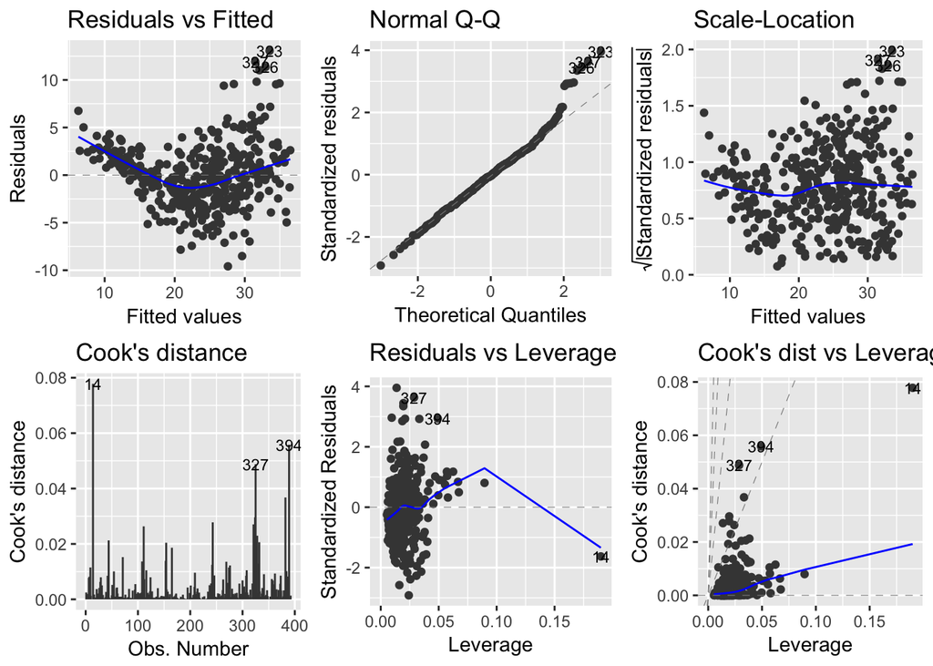

```r
autoplot(lm, which = 1:6, ncol = 3, label.size = 3)
```

The residuals vs Fitted values plot provide a strong indication of non-linearity in the data. In fact, we can observe a u-shape of the residuals, suggesting that there might be a quadratic relationship in the data.  
The residuals plot suggest the presence of large ourliers for fitted values around 30 to 40lm. Furthermore, from the plot we observe evident heteroscedasticity issues as the variability of the residuals increases as the fitted values increase.  
The leverage plot identifies some observations that have a significant leverage, defined as observations with leverage higher than 0.02 ( (p + 1) / n ). However, the plot suggest that observation 14 in particular has a considerably high leverage.

### Use the * and : symbols to fit linear regression models with interaction effects. Do any interactions appear to be statistically significant?

```r
Auto %>%
  select(-name) %>%
  cor()
```

```
##                     mpg  cylinders displacement horsepower     weight
## mpg           1.0000000 -0.7776175   -0.8051269 -0.7784268 -0.8322442
## cylinders    -0.7776175  1.0000000    0.9508233  0.8429834  0.8975273
## displacement -0.8051269  0.9508233    1.0000000  0.8972570  0.9329944
## horsepower   -0.7784268  0.8429834    0.8972570  1.0000000  0.8645377
## weight       -0.8322442  0.8975273    0.9329944  0.8645377  1.0000000
## acceleration  0.4233285 -0.5046834   -0.5438005 -0.6891955 -0.4168392
## year          0.5805410 -0.3456474   -0.3698552 -0.4163615 -0.3091199
## origin        0.5652088 -0.5689316   -0.6145351 -0.4551715 -0.5850054
##              acceleration       year     origin
## mpg             0.4233285  0.5805410  0.5652088
## cylinders      -0.5046834 -0.3456474 -0.5689316
## displacement   -0.5438005 -0.3698552 -0.6145351
## horsepower     -0.6891955 -0.4163615 -0.4551715
## weight         -0.4168392 -0.3091199 -0.5850054
## acceleration    1.0000000  0.2903161  0.2127458
## year            0.2903161  1.0000000  0.1815277
## origin          0.2127458  0.1815277  1.0000000
```

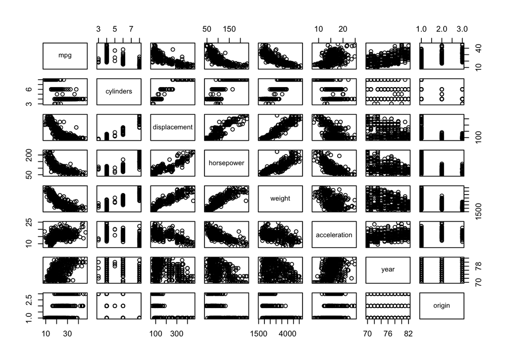

```r
Auto %>%
  select(-name) %>%
  pairs()
```

From the correlation matrix we observe the the variables “cylinder”, “displacement”, “horsepower”, and “weight” are strongly correlated. Therefore, from my knowledge about cars, I decided that the two most significant variables to keep in the model are horsepower and weight.

```r
models <- tribble(
  ~func, ~models,
  "lm", list(formula = mpg ~ .),
  "lm", list(formula = mpg ~ cylinders + horsepower + displacement + weight + year + origin),
  "lm", list(formula = mpg ~ cylinders + horsepower + weight + year + origin),
  "lm", list(formula = mpg ~ weight + year + origin),
  "lm" ,list(formula = mpg ~ weight * year * origin),
  "lm" ,list(formula = mpg ~ weight + year * origin),
  "lm" ,list(formula = mpg ~ weight * year + origin)
  )

models <-
  models %>%
  mutate(result =invoke_map(func, models, data = select(Auto, -name)))

models <-
  models %>%
  mutate(summary =map(result, summary))

models <-
  models %>%
  mutate(radj = map(.$summary, `[`, c("adj.r.squared")) %>% unlist())
```

```r
models$summary[[5]]
```

[output not shown]

[output cut: 249 more lines]

```
##                      Estimate Std. Error t value Pr(>|t|)
## (Intercept)        -2.170e+02  3.551e+01  -6.111 2.43e-09 ***
## weight              7.198e-02  1.334e-02   5.398 1.18e-07 ***
## year                3.331e+00  4.660e-01   7.147 4.50e-12 ***
## origin              9.961e+01  2.508e+01   3.972 8.51e-05 ***
## weight:year        -1.005e-03  1.749e-04  -5.749 1.83e-08 ***
## weight:origin      -4.313e-02  1.080e-02  -3.995 7.75e-05 ***
## year:origin        -1.236e+00  3.254e-01  -3.798 0.000170 ***
## weight:year:origin  5.402e-04  1.399e-04   3.861 0.000132 ***
## ---
## Signif. codes:  0 '***' 0.001 '**' 0.01 '*' 0.05 '.' 0.1 ' ' 1
##
## Residual standard error: 3.055 on 384 degrees of freedom
## Multiple R-squared:  0.8495, Adjusted R-squared:  0.8468
## F-statistic: 309.7 on 7 and 384 DF,  p-value: < 2.2e-16
```

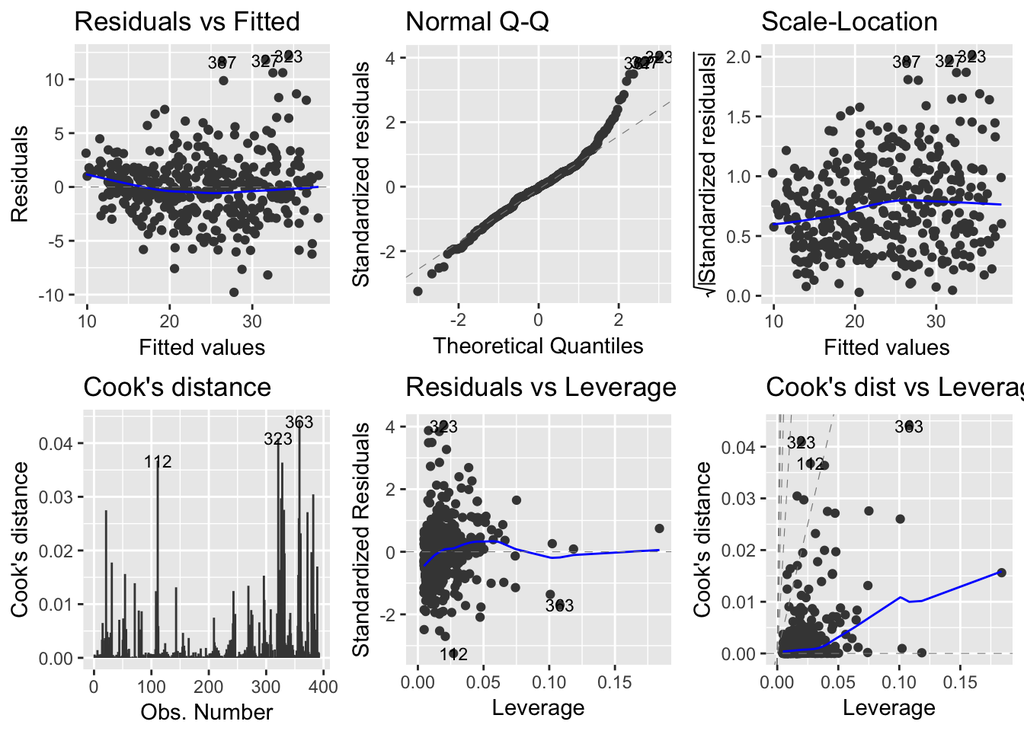

```r
autoplot(models$result[[5]], which = 1:6, ncol = 3, label.size = 3)
```

The model with formula = “mpg ~ weight * year * origin” appear to have all terms statistically significant, both single variables and all interaction terms combinations.

### Try a few different transformations of the variables, such as log(X), √X, X^2. Comment on your findings.

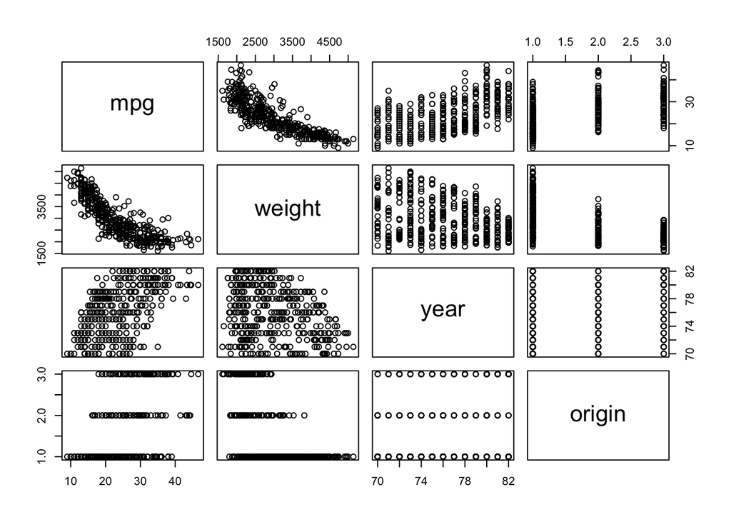

```r
Auto %>%
  select(mpg, weight, year, origin) %>%
  pairs()
```

Observing the pairs plot we can observe how the data between mpg and weight suggest that the relationship between the variables is quadratic with a right skew.

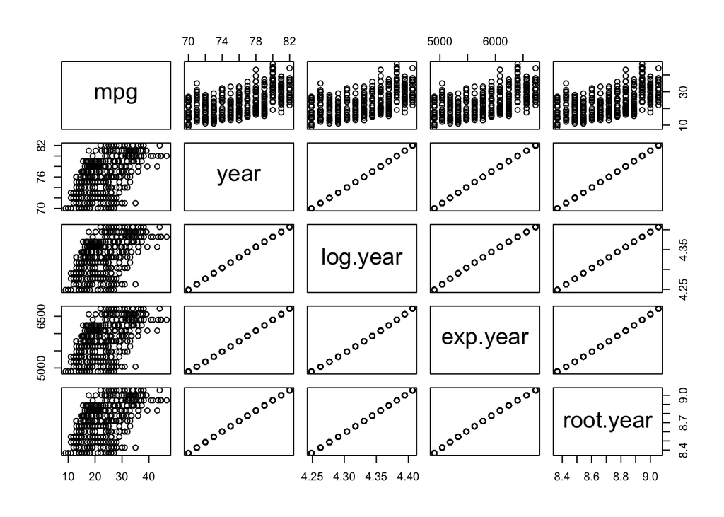

```r
Auto <-
  Auto %>%
  mutate(log.weight = log(weight),
         exp.weight = weight^2,
         root.weight = weight^(1/2),

         log.year = log(year),
         exp.year = year^2,
         root.year = year^(1/2))

Auto %>%
  select(mpg, year, log.year, exp.year, root.year) %>%
  pairs()
```

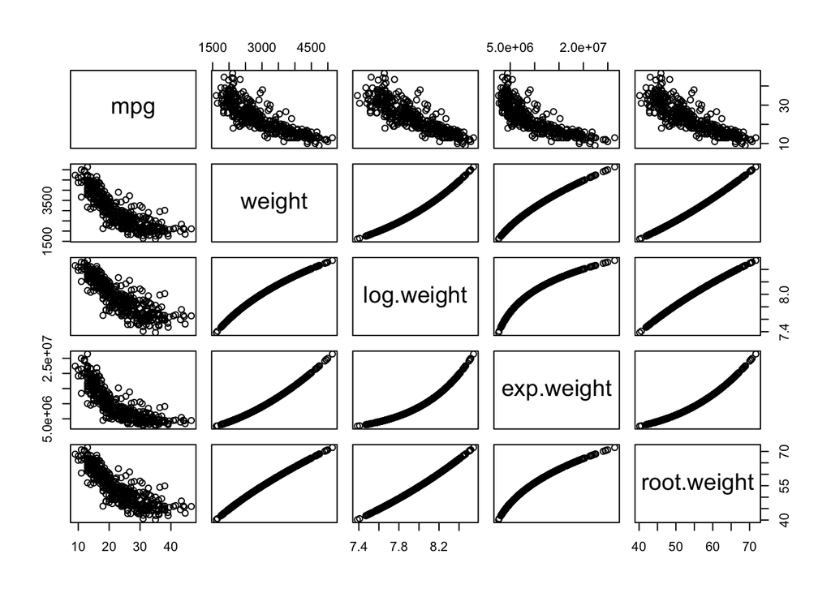

```r
Auto %>%
  select(mpg, weight, log.weight, exp.weight, root.weight) %>%
  pairs()
```

```r
models <- tribble(
  ~func, ~models,
  "lm" ,list(formula = mpg ~ weight * year * origin),

  "lm" ,list(formula = mpg ~ log.weight * year * origin),
  "lm" ,list(formula = mpg ~ root.weight * year * origin),
  "lm" ,list(formula = mpg ~ exp.weight * year * origin),

  "lm" ,list(formula = mpg ~ weight * log.year * origin),
  "lm" ,list(formula = mpg ~ weight * root.year * origin),
  "lm" ,list(formula = mpg ~ weight * exp.year * origin),

  "lm" ,list(formula = mpg ~ exp.weight * exp.year * origin),
  "lm" ,list(formula = mpg ~ root.weight * root.year * origin),
  "lm" ,list(formula = mpg ~ exp.weight * exp.year * origin)
    )

models <-
  models %>%
  mutate(result =invoke_map(func, models, data = select(Auto, -name)))

models <-
  models %>%
  mutate(summary =map(result, summary))

models <-
  models %>%
  mutate(radj = map(.$summary, `[`, c("adj.r.squared")) %>% unlist())


models$summary[[2]] %>% print()
```

[output not shown]

[output cut: 695 more lines]

```
##                          Estimate Std. Error t value Pr(>|t|)
## (Intercept)            -1285.5968   266.8732  -4.817 2.10e-06 ***
## log.weight               160.0439    33.8676   4.726 3.23e-06 ***
## year                      19.1901     3.5125   5.463 8.41e-08 ***
## origin                   692.8308   187.9104   3.687 0.000260 ***
## log.weight:year           -2.3543     0.4458  -5.281 2.15e-07 ***
## log.weight:origin        -89.7194    24.2803  -3.695 0.000252 ***
## year:origin               -8.9417     2.4437  -3.659 0.000289 ***
## log.weight:year:origin     1.1589     0.3157   3.671 0.000276 ***
## ---
## Signif. codes:  0 '***' 0.001 '**' 0.01 '*' 0.05 '.' 0.1 ' ' 1
##
## Residual standard error: 2.951 on 384 degrees of freedom
## Multiple R-squared:  0.8596, Adjusted R-squared:  0.857
## F-statistic: 335.8 on 7 and 384 DF,  p-value: < 2.2e-16
```

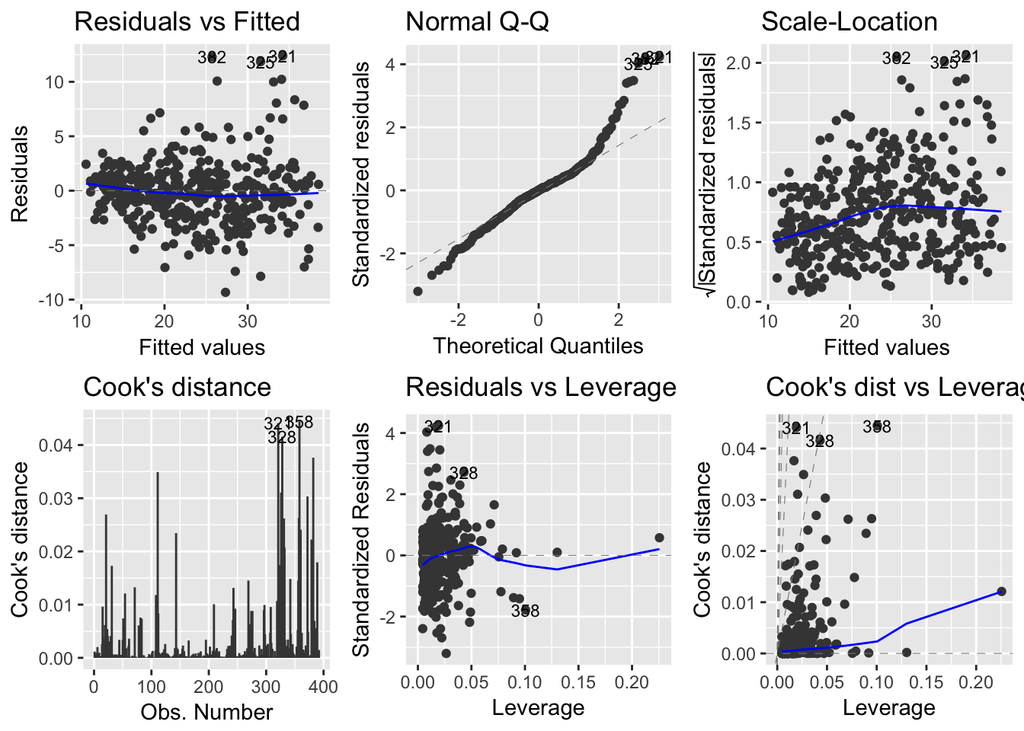

```r
autoplot(models$result[[2]], which = 1:6, ncol = 3, label.size = 3)
```

# 10. This question should be answered using the Weekly data set, which is part of the ISLR package. This data is similar in nature to the Smarket data from this chapter’s lab, except that it contains 1,089 weekly returns for 21 years, from the beginning of 1990 to the end of 2010.

## (a) Produce some numerical and graphical summaries of the Weekly data. Do there appear to be any patterns?

```r
attach(Weekly)
summary(Weekly)
```

```
##       Year           Lag1               Lag2               Lag3
##  Min.   :1990   Min.   :-18.1950   Min.   :-18.1950   Min.   :-18.1950
##  1st Qu.:1995   1st Qu.: -1.1540   1st Qu.: -1.1540   1st Qu.: -1.1580
##  Median :2000   Median :  0.2410   Median :  0.2410   Median :  0.2410
##  Mean   :2000   Mean   :  0.1506   Mean   :  0.1511   Mean   :  0.1472
##  3rd Qu.:2005   3rd Qu.:  1.4050   3rd Qu.:  1.4090   3rd Qu.:  1.4090
##  Max.   :2010   Max.   : 12.0260   Max.   : 12.0260   Max.   : 12.0260
##       Lag4               Lag5              Volume
##  Min.   :-18.1950   Min.   :-18.1950   Min.   :0.08747
##  1st Qu.: -1.1580   1st Qu.: -1.1660   1st Qu.:0.33202
##  Median :  0.2380   Median :  0.2340   Median :1.00268
##  Mean   :  0.1458   Mean   :  0.1399   Mean   :1.57462
##  3rd Qu.:  1.4090   3rd Qu.:  1.4050   3rd Qu.:2.05373
##  Max.   : 12.0260   Max.   : 12.0260   Max.   :9.32821
##      Today          Direction
##  Min.   :-18.1950   Down:484
##  1st Qu.: -1.1540   Up  :605
##  Median :  0.2410
##  Mean   :  0.1499
##  3rd Qu.:  1.4050
##  Max.   : 12.0260
```

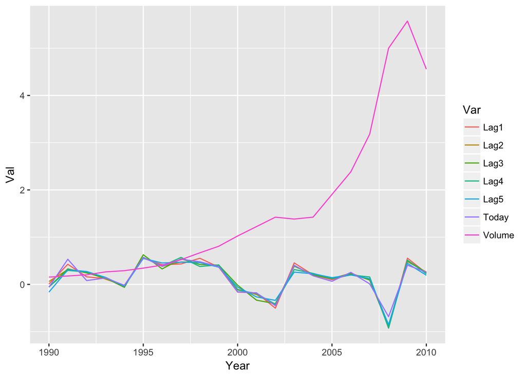

```r
Weekly %>%
  select(., -Direction) %>%
  gather(., `Lag1`,`Lag2`,`Lag3`,`Lag4`,`Lag5`,`Volume`,`Today`, key = "Var", value = "Val") %>%
  group_by(Year, Var) %>%
  summarise(., Val= mean(Val)) %>%
  ggplot(aes(x = Year, y = Val, color = Var)) +
  geom_line()
```

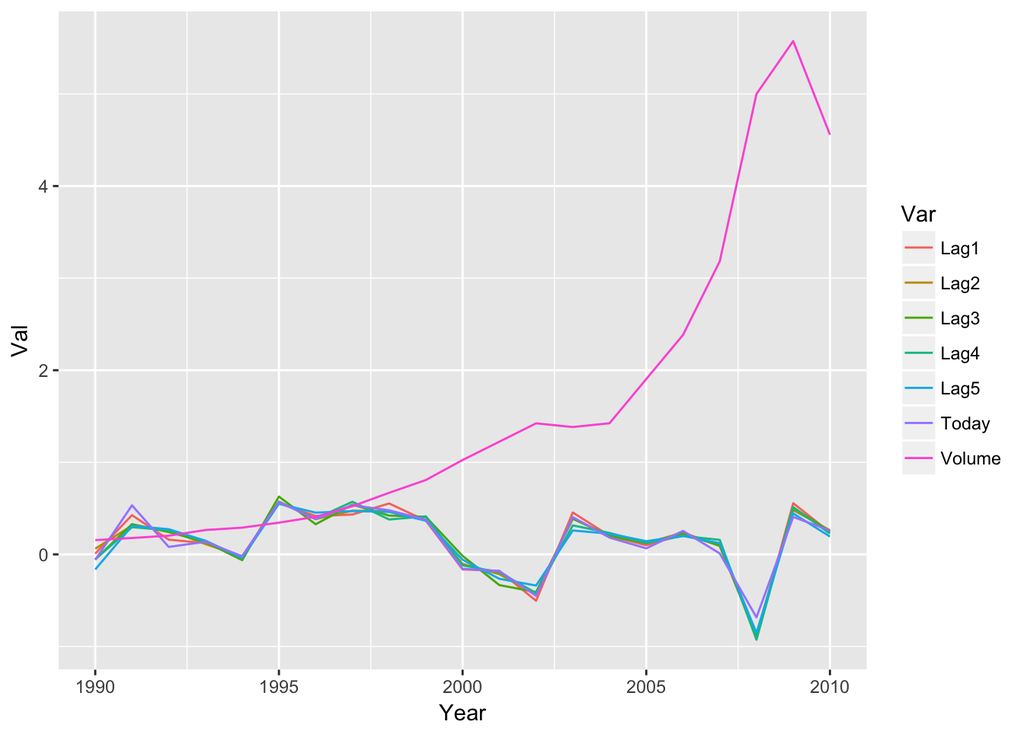

```r
Weekly %>%
  gather(., `Lag1`,`Lag2`,`Lag3`,`Lag4`,`Lag5`,`Volume`,`Today`, key = "Var", value = "Val") %>%
  group_by(Year, Var) %>%
  summarise(., Val= mean(Val)) %>%
  ggplot(aes(x = Year, y = Val, color = Var)) +
  geom_line()
```

```r
Weekly %>%
  select(., -Direction) %>%
  cor()
```

```
##               Year         Lag1        Lag2        Lag3         Lag4
## Year    1.00000000 -0.032289274 -0.03339001 -0.03000649 -0.031127923
## Lag1   -0.03228927  1.000000000 -0.07485305  0.05863568 -0.071273876
## Lag2   -0.03339001 -0.074853051  1.00000000 -0.07572091  0.058381535
## Lag3   -0.03000649  0.058635682 -0.07572091  1.00000000 -0.075395865
## Lag4   -0.03112792 -0.071273876  0.05838153 -0.07539587  1.000000000
## Lag5   -0.03051910 -0.008183096 -0.07249948  0.06065717 -0.075675027
## Volume  0.84194162 -0.064951313 -0.08551314 -0.06928771 -0.061074617
## Today  -0.03245989 -0.075031842  0.05916672 -0.07124364 -0.007825873
##                Lag5      Volume        Today
## Year   -0.030519101  0.84194162 -0.032459894
## Lag1   -0.008183096 -0.06495131 -0.075031842
## Lag2   -0.072499482 -0.08551314  0.059166717
## Lag3    0.060657175 -0.06928771 -0.071243639
## Lag4   -0.075675027 -0.06107462 -0.007825873
## Lag5    1.000000000 -0.05851741  0.011012698
## Volume -0.058517414  1.00000000 -0.033077783
## Today   0.011012698 -0.03307778  1.000000000
```

## Use the full data set to perform a logistic regression with Direction as the response and the five lag variables plus Volume as predictors. Use the summary function to print the results. Do any of the predictors appear to be statistically significant? If so, which ones?

```r
glm.fit <-
  Weekly %>%
  select(-Today, -Year) %>%
  glm(Direction ~ ., family = binomial, data = .)

summary(glm.fit)
```

```
##
## Call:
## glm(formula = Direction ~ ., family = binomial, data = .)
##
## Deviance Residuals:
##     Min       1Q   Median       3Q      Max
## -1.6949  -1.2565   0.9913   1.0849   1.4579
##
## Coefficients:
##             Estimate Std. Error z value Pr(>|z|)
## (Intercept)  0.26686    0.08593   3.106   0.0019 **
## Lag1        -0.04127    0.02641  -1.563   0.1181
## Lag2         0.05844    0.02686   2.175   0.0296 *
## Lag3        -0.01606    0.02666  -0.602   0.5469
## Lag4        -0.02779    0.02646  -1.050   0.2937
## Lag5        -0.01447    0.02638  -0.549   0.5833
## Volume      -0.02274    0.03690  -0.616   0.5377
## ---
## Signif. codes:  0 '***' 0.001 '**' 0.01 '*' 0.05 '.' 0.1 ' ' 1
##
## (Dispersion parameter for binomial family taken to be 1)
##
##     Null deviance: 1496.2  on 1088  degrees of freedom
## Residual deviance: 1486.4  on 1082  degrees of freedom
## AIC: 1500.4
##
## Number of Fisher Scoring iterations: 4
```

The only predictor that appears to be statitically significant is Lag2.

## Compute the confusion matrix and overall fraction of correct predictions. Explain what the confusion matrix is telling you about the types of mistakes made by logistic regression.

```r
glm.probs <- predict(glm.fit,type="response")

glm.pred <- rep("Down", 1089)
glm.pred[glm.probs >.5] <- "Up"

table(glm.pred,Direction)
```

```
##         Direction
## glm.pred Down  Up
##     Down   54  48
##     Up    430 557
```

```r
(54+557) / 1089
```

```
## [1] 0.5610652
```

From the confusion matrix and overall fraction of correct predictions we can observe how the accuracy of the logistic model is close to being that of a random guess. We can observe how the biggest misclassification is related to those stocks that were down.

## Now fit the logistic regression model using a training data period from 1990 to 2008, with Lag2 as the only predictor. Compute the confusion matrix and the overall fraction of correct predictions for the held out data (that is, the data from 2009 and 2010).

```r
glm.train <-
  Weekly %>%
  filter(Year > 1989 & Year > 2007) %>%
  select(-Today, -Year) %>%
  glm(Direction ~ ., family = binomial, data = .)

glm.probs <- predict(glm.fit,type="response", filter(Weekly,Year > 2008))

glm.pred <- rep("Down", 104)
glm.pred[glm.probs >.5] <- "Up"

table(glm.pred,filter(Weekly,Year > 2008)$Direction)
```

```
##
## glm.pred Down Up
##     Down   17 13
##     Up     26 48
```

```r
(17+48) /104
```

```
## [1] 0.625
```